# Week 2: Intro to Data Wrangling with dplyr

Hazel KAVILI

2020-08-04

## Load Packages

We’ll load the packages with `library(tidyverse)` instead of loading the core packages one by one. Today we’ll focus on `dplyr`, a package that helps us to transform data.

```r
#install.packages("tidyverse")
library(tidyverse)
```

## Load Data Into R

Next thing we’ll do is load the data into our R environment. We’ll use a data set about coffee ratings from weekly [Tidy Tuesday challenge](https://github.com/rfordatascience/tidytuesday/blob/master/data/2020/2020-07-07/readme.md).

We’ll use `read_csv` function from `readr` package to get the data, and assign it to `coffee_ratings`. In the rest of the document, we’ll use that name to call our data frame.

```r
#coffee_ratings <- read_csv('https://raw.githubusercontent.com/rfordatascience/tidytuesday/master/data/2020/2020-07-07/coffee_ratings.csv')

coffee_ratings <- read_csv("data/coffee_ratings.csv")
```

## Summary of data

Let’s look at our data frame to get to know it. There are some functions to check the structure and summary of the data: `str`, `summary`, `glimpse` are the most common ones.

```r
glimpse(coffee_ratings)
```

```
## Rows: 1,339
## Columns: 43
## $ total_cup_points      <dbl> 90.58, 89.92, 89.75, 89.00, 88.83, 88.83, 88.75…
## $ species               <chr> "Arabica", "Arabica", "Arabica", "Arabica", "Ar…
## $ owner                 <chr> "metad plc", "metad plc", "grounds for health a…
## $ country_of_origin     <chr> "Ethiopia", "Ethiopia", "Guatemala", "Ethiopia"…
## $ farm_name             <chr> "metad plc", "metad plc", "san marcos barrancas…
## $ lot_number            <chr> NA, NA, NA, NA, NA, NA, NA, NA, NA, NA, NA, NA,…
## $ mill                  <chr> "metad plc", "metad plc", NA, "wolensu", "metad…
## $ ico_number            <chr> "2014/2015", "2014/2015", NA, NA, "2014/2015", …
## $ company               <chr> "metad agricultural developmet plc", "metad agr…
## $ altitude              <chr> "1950-2200", "1950-2200", "1600 - 1800 m", "180…
## $ region                <chr> "guji-hambela", "guji-hambela", NA, "oromia", "…
## $ producer              <chr> "METAD PLC", "METAD PLC", NA, "Yidnekachew Dabe…
## $ number_of_bags        <dbl> 300, 300, 5, 320, 300, 100, 100, 300, 300, 50, …
```

[output cut: 30 more lines]

There are 43 variables (columns) and 1339 rows in our data frame. There is data for both Arabica and Robusta beans, across many countries and professionally rated on a 0-100 scale. All sorts of scoring/ratings for things like acidity, sweetness, fragrance, balance, etc - may be useful for either separating into visualizations/categories or for modeling/recommenders.

## Questions arise

Data analysis starts with questions, let’s try to produce some questions together, by just looking at the data:

- Which coffee species has the highest total_cup_points?
- What is the average total_cup_points for each coffee species?
- What is the proportion of those coffee species in total_cup_points?
- How many species are there for each country_of_origin?
- (many more questions can be produced)

## Base R vs dplyr

Before moving into dplyr verbs, I’d like to show you a comparison of base R and tidyverse syntax.

The two code chunks are doing the same thing: selecting two columns from our dataframe.

```r
coffee_ratings[ , c('species', 'country_of_origin')]
```

While the base R syntax achieves the same end, the dplyr approach provides a more expressive syntax that is easier to read and write.

```r
select(coffee_ratings, species, country_of_origin)
```

## **Select:** *Choosing is not losing!*

We are moving to our first dplyr verb. `select` helps us select the columns/variables of interest from our data frame.

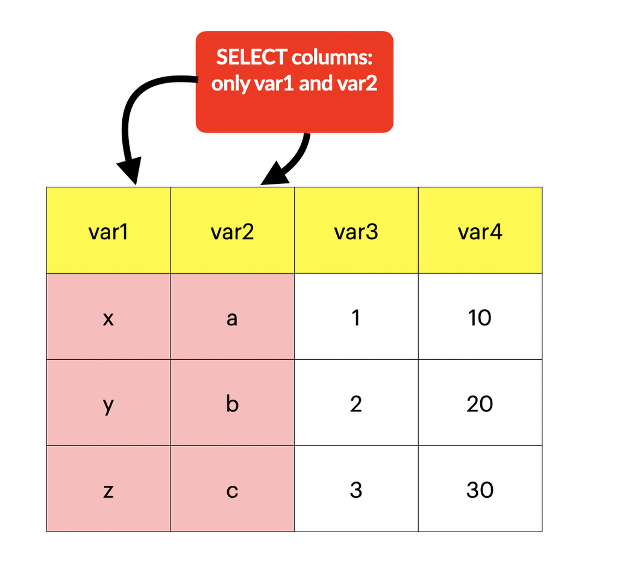

```r
 select(coffee_ratings, species, country_of_origin, color, certification_body)
```

| species | country_of_origin | color | certification_body |
| --- | --- | --- | --- |
| Arabica | Ethiopia | Green | METAD Agricultural Development plc |
| Arabica | Ethiopia | Green | METAD Agricultural Development plc |
| Arabica | Guatemala | NA | Specialty Coffee Association |
| Arabica | Ethiopia | Green | METAD Agricultural Development plc |
| Arabica | Ethiopia | Green | METAD Agricultural Development plc |
| Arabica | Brazil | Bluish-Green | Specialty Coffee Institute of Asia |

`select` has helpers like the one on the below. You can select range of columns by using `:`

```r
select(coffee_ratings, 1:4, 21:25)
```

| total_cup_points | species | owner | country_of_origin | aroma | flavor | aftertaste | acidity | body |
| --- | --- | --- | --- | --- | --- | --- | --- | --- |
| 90.58 | Arabica | metad plc | Ethiopia | 8.67 | 8.83 | 8.67 | 8.75 | 8.50 |
| 89.92 | Arabica | metad plc | Ethiopia | 8.75 | 8.67 | 8.50 | 8.58 | 8.42 |
| 89.75 | Arabica | grounds for health admin | Guatemala | 8.42 | 8.50 | 8.42 | 8.42 | 8.33 |
| 89.00 | Arabica | yidnekachew dabessa | Ethiopia | 8.17 | 8.58 | 8.42 | 8.42 | 8.50 |
| 88.83 | Arabica | metad plc | Ethiopia | 8.25 | 8.50 | 8.25 | 8.50 | 8.42 |
| 88.83 | Arabica | ji-ae ahn | Brazil | 8.58 | 8.42 | 8.42 | 8.50 | 8.25 |

`select` function returns a modified copy, doesn’t change the data.

## **Filter:** *Do we want everything?*

`filter` helps us to extract rows that meet logical criteria.

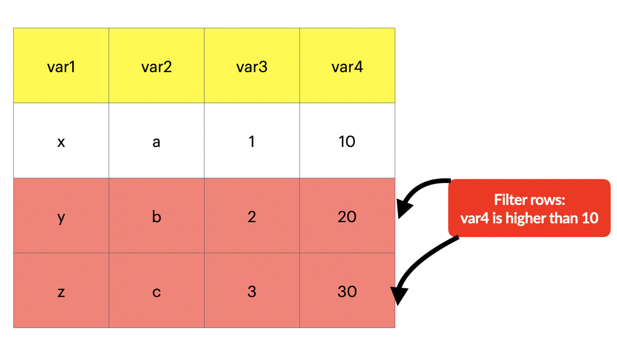

We can use all the logical operator inside of filter function:

```r
<, >,
<=, >=,
==, !=,
!x == "a",
x == "a" & y == "b",
x == "a" | y == "b"
```

Let’s say we want to look at our coffee_ratings dataset only for Ethiopia originated coffees. Then what we need to do is `filter` our dataset by using necessary column and value:

```r
filter(coffee_ratings, country_of_origin == "Ethiopia")
```

| total_cup_points | species | owner | country_of_origin | farm_name |
| --- | --- | --- | --- | --- |
| 90.58 | Arabica | metad plc | Ethiopia | metad plc |
| 89.92 | Arabica | metad plc | Ethiopia | metad plc |
| 89.00 | Arabica | yidnekachew dabessa | Ethiopia | yidnekachew dabessa coffee plantation |
| 88.83 | Arabica | metad plc | Ethiopia | metad plc |
| 88.67 | Arabica | ethiopia commodity exchange | Ethiopia | aolme |
| 88.42 | Arabica | ethiopia commodity exchange | Ethiopia | aolme |

```r
filter(coffee_ratings, number_of_bags >= 60)
```

| total_cup_points | species | owner | country_of_origin | number_of_bags |
| --- | --- | --- | --- | --- |
| 90.58 | Arabica | metad plc | Ethiopia | 300 |
| 89.92 | Arabica | metad plc | Ethiopia | 300 |
| 89.00 | Arabica | yidnekachew dabessa | Ethiopia | 320 |
| 88.83 | Arabica | metad plc | Ethiopia | 300 |
| 88.83 | Arabica | ji-ae ahn | Brazil | 100 |
| 88.75 | Arabica | hugo valdivia | Peru | 100 |

## **Arrange:** *Let’s bring some order to data!*

`arrange` order rows from smallest to largest values. Let’s say we want to look at our data frame arranged by `total_cup_points`. In default, your dataset will be arranged by ascending order.

```r
arrange(coffee_ratings, total_cup_points)
```

| total_cup_points | species | owner | country_of_origin |
| --- | --- | --- | --- |
| 0.00 | Arabica | bismarck castro | Honduras |
| 59.83 | Arabica | juan luis alvarado romero | Guatemala |
| 63.08 | Arabica | exportadora atlantic, s.a. | Nicaragua |
| 67.92 | Arabica | myriam kaplan-pasternak | Haiti |
| 68.33 | Arabica | juan carlos garcia lopez | Mexico |
| 69.17 | Arabica | cadexsa | Honduras |

If we want to order it by descending order of total_cup_points, we can use the syntax below:

```r
arrange(coffee_ratings, desc(total_cup_points))
```

| total_cup_points | species | owner | country_of_origin |
| --- | --- | --- | --- |
| 90.58 | Arabica | metad plc | Ethiopia |
| 89.92 | Arabica | metad plc | Ethiopia |
| 89.75 | Arabica | grounds for health admin | Guatemala |
| 89.00 | Arabica | yidnekachew dabessa | Ethiopia |
| 88.83 | Arabica | metad plc | Ethiopia |
| 88.83 | Arabica | ji-ae ahn | Brazil |

## Steps

Now we can do some operations on our data frame by using 3 verbs we learned. However, we need to save our data on every step if we want to use it later for next steps, right? Do you see how many times we write coffee_ratings_ethiopia in the code below?

```r
coffee_ratings_ethiopia <-
  select(coffee_ratings, total_cup_points, species, country_of_origin)

coffee_ratings_ethiopia <-
  filter(coffee_ratings_ethiopia, country_of_origin == "Ethiopia")

coffee_ratings_ethiopia <-
  arrange(coffee_ratings_ethiopia, total_cup_points)

coffee_ratings_ethiopia
```

## **Pipe Operator** *( %>% )*

Pipe helps us to connect our dplyr verbs. Passes results on left into first argument of function on right.

Let’s try to do the *same* thing with pipes and read the code below: I have the dataframe called coffee_ratings, I call it. I select 3 variables from that data frame and filter it by country_of_origin variable equals to Ethiopia. Then I arrange it by total_cup_points variable in ascending order.

```r
coffee_ratings_ethiopia <-
  coffee_ratings %>%
  select(total_cup_points, species, country_of_origin) %>%
  filter(country_of_origin == "Ethiopia") %>%
  arrange(total_cup_points)
```

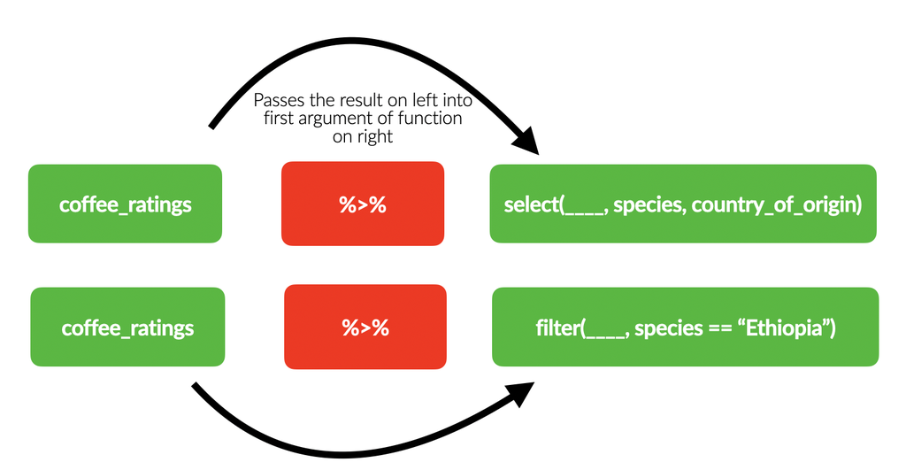

What we see in here is that everything is chained. We can read that code from left to right like a sentence. Shortcut for pipe operator on keyboard is:

- CMD + shift + M (for Mac)
- CTRL + shft + M (for Windows)

## Your Turn: How should we fill the blank areas?

Now it’s time for a pop-quiz!

We need to:

- Select **total_cup_points, species, owner, countyr_of_origin** and **number_of_bags**
- Then Filter **country of origin for only Brazil** and **total_cup_points** is higher than 70
- Then Arrange it by **number_of_bags** in descending order.

You have two minues:

```r
coffee_ratings %>%
  ____(1:4, number_of_bags) %>%
  ____(country_of_origin == "Brazil") %>%
  ____(total_cup_points > 70) %>%
  ____(desc(number_of_bags))
```

## Here is the solution:

```r
coffee_ratings %>%
  select(1:4, number_of_bags) %>%
  filter(country_of_origin == "Brazil") %>%
  filter(total_cup_points > 70) %>%
  arrange(desc(number_of_bags))
```

```
## # A tibble: 132 x 5
##    total_cup_points species owner                country_of_orig… number_of_bags
##               <dbl> <chr>   <chr>                <chr>                     <dbl>
##  1             82.2 Arabica klem organics        Brazil                     1062
##  2             81.1 Arabica gregorio sebba       Brazil                      500
##  3             80.2 Arabica volcafe ltda. - bra… Brazil                      440
##  4             80.1 Arabica brayan cunha souza   Brazil                      440
##  5             75.7 Arabica volcafe ltda. - bra… Brazil                      440
##  6             84.5 Arabica alexandra katona-ca… Brazil                      320
##  7             84   Arabica ipanema coffees      Brazil                      320
##  8             83.9 Arabica ipanema coffees      Brazil                      320
##  9             83.9 Arabica ipanema coffees      Brazil                      320
## 10             83.8 Arabica ipanema coffees      Brazil                      320
## # … with 122 more rows
```

## **Group_by & Summarise:** *Let’s create associations among groups!*

We often want to look at our data by some group (if we have) for example country, year, age, gender, education, etc. to spot some differences or similarities (if there is). It helps compare different subsets of our data.

`group_by` gives the data frame a grouping using one or more columns, which modifies the subsequent call to `summarise`.

We can use functions like `mean`, `median`, `sum`, `sd`, `max`, `min` to find out some group statistics inside of `summarise` function.

Here is an example. One of the questions on the above was “What is the average total_cup_points for each coffee species?”. Let’s try to find some answer to that question:

```r
coffee_ratings %>%
  group_by(species) %>%
  summarise(avg_rating = mean(total_cup_points))
```

```
## # A tibble: 2 x 2
##   species avg_rating
##   <chr>        <dbl>
## 1 Arabica       82.1
## 2 Robusta       80.9
```

`summarise` function builds a new dataset that contains only the summarising statistics that you calculated:

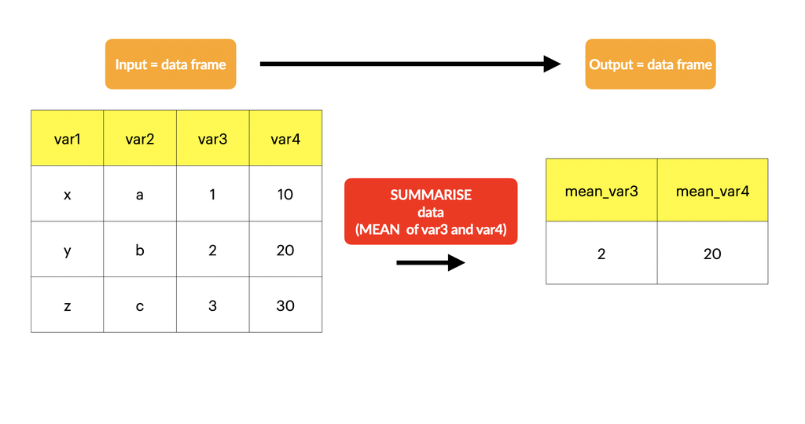

Let’s look at the `average and median total_cup_points` grouped by `country_of_origin` this time:

```r
coffee_ratings %>%
  group_by(country_of_origin) %>%
  summarise(avg_rating = mean(total_cup_points),
            median_rating = median(total_cup_points))
```

```
## # A tibble: 37 x 3
##    country_of_origin avg_rating median_rating
##    <chr>                  <dbl>         <dbl>
##  1 Brazil                  82.4          82.4
##  2 Burundi                 81.8          81.8
##  3 China                   82.9          83.2
##  4 Colombia                83.1          83.2
##  5 Costa Rica              82.8          83.2
##  6 Cote d?Ivoire           79.3          79.3
##  7 Ecuador                 80.2          78.8
##  8 El Salvador             83.1          82.8
##  9 Ethiopia                85.5          85.2
## 10 Guatemala               81.8          82.5
## # … with 27 more rows
```

## **Mutate:** *We need a new column!*

`mutate` lets us add or overwrite columns by computing a new value for them.

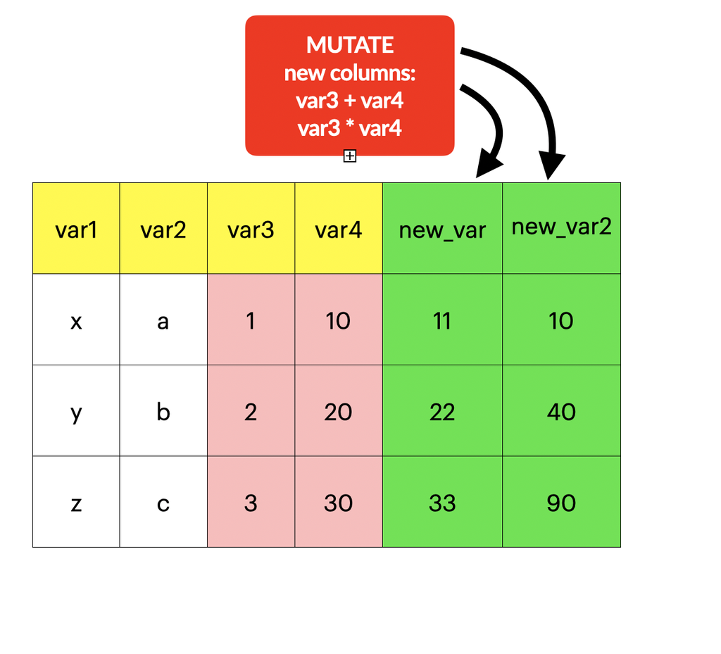

For example, in the code below, we want a column name `is_processing_method_full` which is filled by checking if `processing_method` have some value or not. If it is not NA, we’ll write 1, otherwise 0.

We didn’t have `is_processing_method_full` before but we create it by using `processing_method` variable.

```r
coffee_ratings %>%
  select(species, country_of_origin, processing_method) %>%
  mutate(is_processing_method_full = ifelse(!is.na(processing_method), 1, 0)) %>%
  head()
```

```
## # A tibble: 6 x 4
##   species country_of_origin processing_method is_processing_method_full
##   <chr>   <chr>             <chr>                                 <dbl>
## 1 Arabica Ethiopia          Washed / Wet                              1
## 2 Arabica Ethiopia          Washed / Wet                              1
## 3 Arabica Guatemala         <NA>                                      0
## 4 Arabica Ethiopia          Natural / Dry                             1
## 5 Arabica Ethiopia          Washed / Wet                              1
## 6 Arabica Brazil            Natural / Dry                             1
```

## Your Turn: Let’s put it all together!

We are wondering what is the `mean value of aroma and aftertaste` variables by `country_of_origin` and depending on `if they have color or not` for the `species of Arabica`?

Can we find the order of that code piece to achieve our goal? You have 2 minutes:

```r
1- filter(species == "Arabica")
2- select(total_cup_points, species, country_of_origin, processing_method, aroma, aftertaste, color)
3- coffee_ratings
4- arrange(desc(mean_aroma))
5- summarise(mean_aroma = mean(aroma),
            mean_aftertaste = mean(aftertaste))
6- group_by(country_of_origin, is_color_full)
7- mutate(is_color_full = ifelse(!is.na(color), 1, 0))
```

## Here is the solution:

```r
coffee_ratings %>%
  select(total_cup_points, species, country_of_origin, processing_method, aroma, aftertaste, color) %>%
  filter(species == "Arabica") %>%
  mutate(is_color_full = ifelse(!is.na(color), 1, 0)) %>%
  group_by(country_of_origin, is_color_full) %>%
  summarise(mean_aroma = mean(aroma),
            mean_aftertaste = mean(aftertaste)) %>%
  arrange(desc(mean_aroma))
```

```
## # A tibble: 59 x 4
## # Groups:   country_of_origin [37]
##    country_of_origin is_color_full mean_aroma mean_aftertaste
##    <chr>                     <dbl>      <dbl>           <dbl>
##  1 Papua New Guinea              1       8.33            7.83
##  2 Uganda                        0       8.08            7.83
##  3 Ethiopia                      1       8.01            7.92
##  4 Panama                        0       8               7.83
##  5 United States                 1       8               8.08
##  6 Uganda                        1       7.90            7.59
##  7 United States                 0       7.87            7.98
##  8 Rwanda                        1       7.83            7.75
##  9 Ethiopia                      0       7.82            7.88
## 10 Kenya                         1       7.81            7.74
## # … with 49 more rows
```

## Great job!

Well done everyone! Thank you for joining the training!

You can find the lesson materials on my [Github page.](https://github.com/UniversalTourist/tidyverse_trainer_exam_materials)

Any questions? I’d be happy to answer!